# Introduction to differential equations

March, 2025

## Introduction

- *Since Newton, mankind has come to realise that the laws of physics are always expressed in the language of differential equations.* - Steven Strogatz
- “They are really freaking hard to solve!”
- https://www.youtube.com/watch?v=p_di4Zn4wz4
- https://www.youtube.com/watch?v=ly4S0oi3Yz8

## Algebraic Equations

- Solutions to algebraic equations are just numbers.
- Find an \(x\) that makes the following equation true.

\[ \begin{align*} x + 2 &= 4 \\ x &= 2 \end{align*} \]

## Algebraic Equations

- Algebraic equations can have multiple solutions.
- Each solution is still just a number.

\[ \begin{align*} x^2 + 3x + 2 &= 0 \\ (x + 1)(x + 2) &= 0 \\ x &= -1 \text{ or } x = -2 \end{align*} \]

## Differential Equations

- A differential equation is an equation that relates a function to its derivatives.
- You may see a few different notations for derivatives. E.g.,

\[ \begin{align*} \frac{dy}{dt} &= 2y \\ y^\prime(t) &= 2y(t) \\ \frac{d}{dt}f(t) &= 2 f(t) \\ f^\prime(t) &= 2f(t) \end{align*} \]

## Differential Equations

- Find a function \(f(t)\) that makes the following equation true.
- A solution to a differential equation is a function.

\[ \begin{align*} \frac{df}{dt} &= 2 f(t) \\ f(t) &= e^{2 t} \text{ is a solution} \\ \end{align*} \]

## Differential Equations

- Verify that \(f(t) = e^{2 t}\) is a solution to the differential equation \(\frac{d}{dt} f(t) = 2 f(t)\).

[figure not shown]

## Why are they important?

- Differential equations can be used to model the evolution of systems over time (e.g., \(\frac{d}{dt}\))
- It’s often easier to descirbe the rate of change of a system than to describe the present and future states of the system directly.

## Example: Hodkin Huxley Model

- The Hodgkin-Huxley model is a set of nonlinear differential equations that describe how action potentials in neurons are initiated and propagated.
- An action potential is a rapid rise and fall in membrane potential that occurs when a neuron sends information down its axon.
- The model is based on the experimental data from the giant axon of the squid, but it has been foundational in understanding neuronal behavior across many species.

#### Key Aspects of the Hodgkin-Huxley Model:

1. **Rate of Change**: The model describes how the membrane potential of a neuron \(V\) changes over time in response to the flow of ions \(Na^+\), \(K^+\), and others) through channels in the neuron’s membrane. The rate of change of the membrane potential can be described by differential equations that account for the conductance of these ion channels and the differences in ion concentrations inside and outside the neuron.
2. **State of the System**: While directly measuring the instantaneous state of all ion channels in a neuron is nearly impossible due to their vast number and rapid dynamics, the Hodgkin-Huxley model allows for the prediction of the neuron’s behavior (such as firing an action potential) based on the neuron’s membrane potential and the properties of the ion channels.

## Question 1

Consider the differential equation \(\frac{dy}{dt} = ky\), where \(k\) is a constant.

- **Application**: Models natural phenomena like population growth (if \(k > 0\)) or radioactive decay (if \(k < 0\)).
- **Exact Solution**: \(y(x) = y(0)e^{kx}\), where \(y(0)\) is the initial condition.
- **Example**: If a bacteria population doubles every hour, the rate \(k\) is \(\ln(2)\), and the population at any time \(x\) can be described by \(y(x) = y(0)e^{\ln(2)x}\).

Select the plot that represents a solution to this differential equation when \(k > 0\).

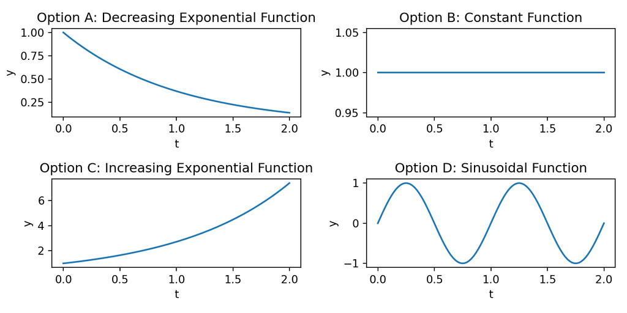

## Answer 1

**Answer**

- **Option C** shows an increasing exponential function, which is the **correct** representation of the solution to \(\frac{dy}{dt} = ky\) for \(k > 0\).

## Question 2

Consider the differential equation \(\frac{dT}{dt} = k(T - T_{\text{env}})\), where \(T\) is the temperature of the object, \(T_{\text{env}}\) is the ambient (environmental) temperature, and \(k\) is a constant related to the cooling or heating efficiency.

- **Application**: Describes how the temperature of an object changes in a cooler or warmer environment.
- **Example**: A cup of coffee cools in a room. If the room temperature is 20°C and the coffee initially is 80°C, the coffee’s temperature over time can be modeled with this equation.
- **Exact Solution**: \(T(t) = T_{\text{env}} + (T(0) - T_{\text{env}})e^{kt}\), where \(T(0)\) is the initial temperature of the object.

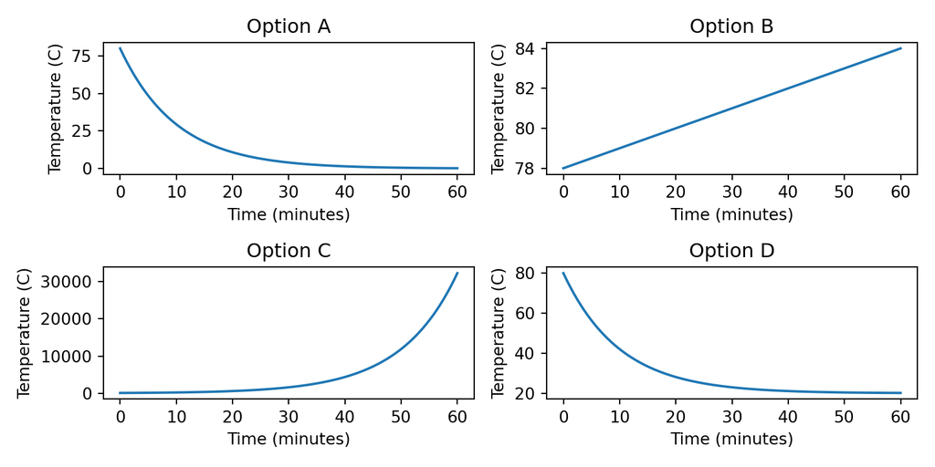

## Answer 2

**Answer**

- **Option D** is the correct representation of the solution to the differential equation \(\frac{dT}{dt} = k(T - T_{\text{env}})\).

## Question 3

Consider the differential equation \(\frac{dV}{dt} = \frac{1}{RC}(V_{\text{source}} - V)\), where \(V\) is the voltage across the capacitor, \(V_{\text{source}}\) is the source voltage, \(R\) is the resistance, and \(C\) is the capacitance.

- **Application**: Models the voltage change over a capacitor as it charges from a voltage source through a resistor.
- **Exact Solution**: \(V(t) = V_{\text{source}} - (V_{\text{source}} - V(0))e^{-\frac{t}{RC}}\), where \(V(0)\) is the initial voltage across the capacitor.
- **Example**: If a 1V capacitor charges through a 1Ω resistor from a 5V source, the voltage across the capacitor over time can be described with this equation.

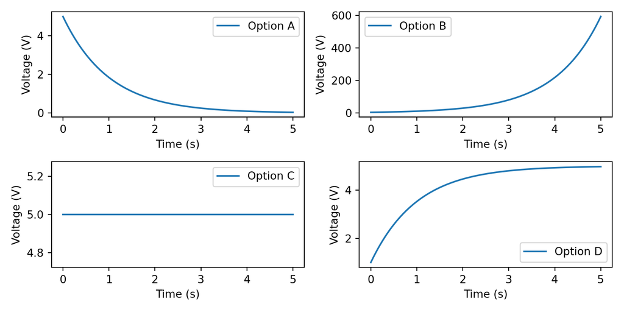

## Answer 3

**Answer**

- **Option D** is the correct representation of the solution to the differential equation \(\frac{dV}{dt} = \frac{1}{RC}(V_{\text{source}} - V)\).